# Méthodes d’appariement

Atelier Mapme : Evaluation d’impact sur données spatiales

Thomas Thivillon, Florent Bédécarrats (sur une base élaborée par Jeanne de Montalembert et Marin Ferry)

January 1, 2025

## Problème de départ

Est-ce que le statut d’Aire Protégée a un impact sur le couvert forestier ?

C’est-à-dire :

$$E[CF1|AP = 1] - E[CF1|AP = 0]$$

avec $CF1$ le couvert forestier d’une zone si c’est une AP et $CF0$ le couvert forestier si ce n’est pas une AP, **pour la même zone et au même moment**.

Le problème évident est qu’on n’observe jamais simultanément les deux états pour la même unité.

$\Rightarrow$ Quel contrefactuel utiliser ?

- Comparer des zones différentes ?
- Risque de confusion avec des effets structurels.

## Illustration intuitive

**Comparaison naïve entre deux zones :**

| Zone | Couvert forestier observé |
| --- | --- |
| **Makira** | $$CF_M = M + AP$$ |
| **Autre** | $$CF_A = A$$ |

*Remarque :*  
$M$ = caractéristiques propres à Makira (relief, climat, accès…)  
$A$ = caractéristiques propres à la zone non protégée  
$AP$ = effet de l’aire protégée

**Différence observée :**

$$CF_M - CF_A = (M + AP) - A = AP + (M - A)$$

**Problème :**  
On voudrait isoler $AP$,  
mais on capte aussi $(M - A)$.

$\Rightarrow$ **Biais de sélection** dû aux différences structurelles entre zones.

$\Rightarrow$ L’appariement vise à trouver une zone non protégée où $M \approx A$.

## Principe du matching

On cherche une zone non traitée **qui ressemble le plus possible** à la zone traitée : son “jumeau”.

L’idée est de comparer les résultats entre unités aux caractéristiques observables $X$ proches, en supposant que **toute la sélection dans le traitement passe par $X$**.

## Hypothèses fondamentales

- **Indépendance conditionnelle (CIA)** :
  $$(Y(1), Y(0)) \perp T \mid X$$

  $\Rightarrow$ À caractéristiques observables identiques, l’assignation est as-if aléatoire.
- **Support commun (overlap)** :  
  Pour chaque $X$, il existe des unités traitées et non traitées.

## Hypothèse CIA : ATT vs ATE

- Pour identifier l’**ATT** (effet moyen sur les traités), on suppose seulement :
  $$Y(0) \perp T \mid X$$
- Pour identifier l’**ATE**, il faut que $Y(0)$ et $Y(1)$ soient indépendants de $T$ conditionnellement à $X$.

$\Rightarrow$ Hypothèse plus forte.

## Risques liés à la CIA

- La CIA suppose qu’aucune variable inobservée ne détermine à la fois $T$ et $Y$.
- Il faut aussi qu’une unité non traitée comparable existe réellement pour chaque profil pertinent de $X$.
- Si certaines valeurs de $X$ déterminent avec certitude le traitement, pas d’unité comparable.

$\Rightarrow$ Il faut des jumeaux **observables** et **non systématiquement traités**.

## Hypothèse de support commun

On suppose qu’il existe, pour chaque valeur de $X$, des unités traitées et non traitées.

Sinon, impossible de construire un groupe de comparaison.

$\Rightarrow$ Vérification graphique et exclusion des zones hors support.

## Objectif du matching

Comparer $Y(1)$ d’une unité traitée avec $Y(0)$ d’une unité non traitée **ayant les mêmes $X$**.

$$ATT = E[Y(1) - Y(0) \mid T=1]$$

$$\approx \frac{1}{N_1} \sum_{i \in T=1} \left( Y_i - Y_{j(i)} \right)$$

où $j(i)$ est le “jumeau” de l’unité $i$.

## Méthodes d’appariement

Plusieurs façons de définir les paires (ou groupes) appariés :

- `"exact"` : appariement exact sur les covariables
- `"coarsened-exact"` : appariement exact après discrétisation
- `"nearest-neighbor"` : plus proche voisin
- `"optimal"` : minimise la distance totale globale
- `"full"` : chaque unité est utilisée, poids variables

## Mesures de distance

Pour définir “le plus proche”, il faut expliciter une métrique de distance.

- **Distance euclidienne** : simple somme des différences
- **Distance de Mahalanobis** : tient compte de la variance et des corrélations entre covariables
- **Score de propension** : probabilité d’être traité conditionnellement à $X$

## Voisin le plus proche

- Méthode intuitive : on apparie chaque unité traitée avec sa plus proche unité contrôle.
- On peut apparier avec un seul jumeau ou avec $m$ plus proches voisins.
- On peut aussi exclure les paires trop éloignées en fixant un seuil de distance (*caliper*).

$\Rightarrow$ La méthode est simple, mais la qualité de l’appariement dépend directement de la façon de mesurer la proximité.

## Appariement avec ou sans remise

- **Sans remise** : chaque unité non traitée est utilisée une seule fois.
- **Avec remise** : on peut utiliser la même unité plusieurs fois.

Avantage du *avec remise* : plus de flexibilité, meilleure qualité des appariements dans petits échantillons.

Inconvénients du *sans remise* :

- nécessite un large échantillon de contrôle ;
- peut rendre l’estimation sensible à l’ordre d’appariement.

## Limites du plus proche voisin

L’appariement est assez simple à mettre en œuvre, son principe est intuitif et ne demande pas de choix de paramètres très lourds.

Toutefois :

- unité la plus proche $\neq$ unité vraiment proche ;
- certains plus proches voisins peuvent rester assez éloignés ;
- la méthode traite de la même manière des couples très proches et moins proches ;
- apparier avec un seul contrôle prive de l’information apportée par les autres unités comparables.

$\Rightarrow$ Biais possible et perte de précision.

## Choix de la taille de la fenêtre

La fenêtre $d$ mesure la taille du voisinage en dehors duquel les poids sont très faibles.

Plus la fenêtre $d$ est petite, plus l’estimation du contrefactuel d’une unité traitée ne prendra en compte que les unités non traitées dont les caractéristiques observables sont très proches des siennes.

Il n’existe pas vraiment de règle établie pour le choix de cette fenêtre.

En pratique, le choix de la fenêtre est fait de manière *ad-hoc*.

## Biais vs variance

Chaque méthode a des avantages et des inconvénients.

L’opposition entre la plus simple (voisin le plus proche) et la plus élaborée (noyau) reflète le dilemme classique entre biais et variance :

- Ne pas utiliser l’ensemble de l’information disponible réduit la précision.
- Les estimations par fonction à noyau sont toujours plus précises, même sur de petits échantillons (Frolich, 2004), mais on peut craindre qu’elles augmentent aussi les risques de mauvais appariements et donc les biais.

En pratique, on recommande de tester la sensibilité des résultats à la méthode utilisée.

## Curse of dimensionality

Le matching exact est souvent compliqué à mettre en œuvre.

Pour que l’hypothèse CIA soit vérifiée, on souhaite utiliser le maximum d’information et donc apparier sur de très nombreuses variables. Mais plus on intègre des variables, plus il s’avérera difficile de trouver un voisin proche.

À distance finie, les estimateurs sont d’autant plus biaisés que le nombre de variables de conditionnement $X$ est élevé (d’autant plus lorsque les variables de conditionnement sont continues).

$\Rightarrow$ L’appariement sur le score de propension (PSM) est pragmatique et désirable.

## Appariement sur le score de propension

Si l’hypothèse CIA est vérifiée, alors les résultats potentiels sont indépendants de l’adhésion au traitement conditionnellement au score de propension (Rosenbaum et Rubin, 1983).

Soit le score de propension $\pi(X_i) \equiv P(T_i = 1 \mid X_i)$ et $0 < \pi(X_i) < 1$, i.e. la probabilité d’être traité conditionnellement aux observables, on a :

$$(Y(0), Y(1)) \perp T \mid X \Rightarrow (Y(0), Y(1)) \perp T \mid \pi(X_i)$$

Cette propriété diminue le nombre de dimensions des comparaisons, puisque l’on ramène le nombre de variables de conditionnement à une seule : résumé univarié de l’ensemble des covariables.

## Estimation du score de propension

Pour tenir compte de la nature bornée du PSM, il est d’usage de le modéliser par une forme logistique (ou un probit) :

$$\pi(X_i) = P(T_i = 1 \mid X_i)$$

Même s’il est coutume d’estimer le PSM par un modèle logit ou probit, il convient de se rappeler que la forme fonctionnelle du PSM est souvent inconnue.

## Vérification du support commun

Les méthodes présentées sous l’hypothèse d’indépendance conditionnelle reposent sur l’hypothèse d’un support commun.

Celle-ci signifie qu’il existe à la fois des unités traitées et des non traitées ayant des valeurs des observables identiques, i.e. qui partagent le même PSM.

Si ce n’est pas le cas, il sera impossible de trouver pour chaque unité traitée des non traitées comparables.

$\Rightarrow$ Il est important de vérifier que le support commun est suffisamment large.

## Test visuel du support commun

On peut représenter le support commun à partir de la distribution des scores de propension des unités traitées et non-traitées.

En pratique, on représente les histogrammes de probabilité estimée d’être traité pour les unités bénéficiaires et des non bénéficiaires du traitement étudié.

On peut ensuite vérifier l’étendue des valeurs de $\pi(X_i)$ pour lesquelles on observe un nombre suffisant d’unités traitées et non-traitées, i.e. la largeur du support commun.

## Test visuel du support commun

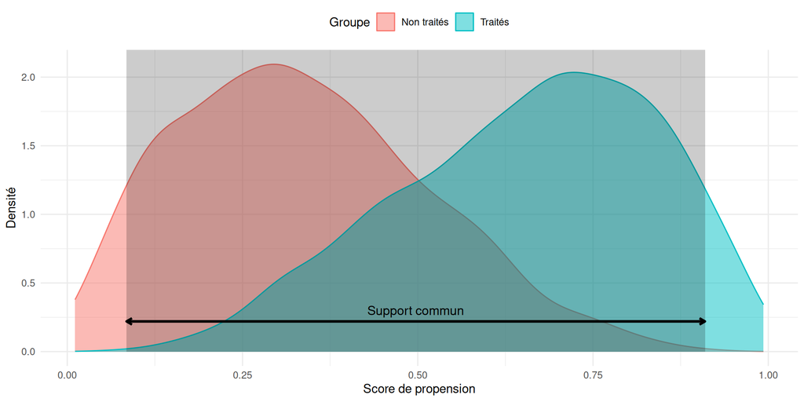

Figure 1: Exemple de support commun

## Enjeux liés au support commun

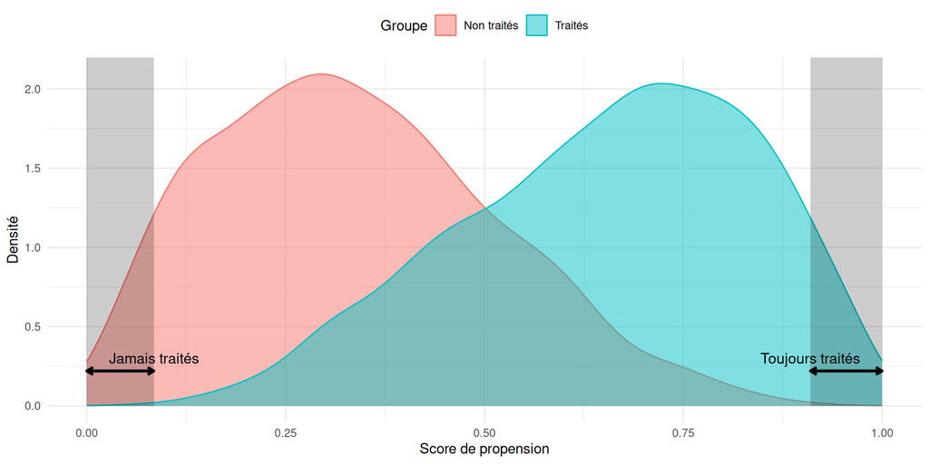

Figure 2: Exemple de support commun et validité externe

## Imposer un support commun

### Méthode du min/max

- Pour estimer l’ATT, Dehejia et Wahba (1999) proposent d’éliminer :
  1. les unités non traitées ayant un score inférieur au minimum observé sur les unités traitées, c.à.d. *“Jamais traités”*
  2. les unités traitées ayant un score supérieur au maximum observé pour les unités non traitées, c.à.d *“always treated”*

**Attention** : Ce qui est alors estimé, ce n’est plus un *ATE* (average treatment effect), ni même un *ATT* (average treatement effect on the treated) mais un *ATM* (average teatment effect on the matched observations)

## Quelles variables de conditionnement/contrôle ?

L’hypothèse d’indépendance conditionnelle demande d’observer les caractéristiques qui déterminent l’allocation du traitement.

En pratique, il doit s’agir de variables qui peuvent avoir un impact sur la variable d’intérêt (e.g. déforestation) et sur le choix de bénéficier du dispositif (e.g. Aire Protégée).

**Deux points de vigilance :** - Il ne faut pas utiliser de variables mesurées après la mise en place du dispositif et qui peuvent également affecter celui-ci → problème d’endogénéité - Il faut qu’il existe une part d’aléa ou d’exogénéité dans la sélection des unités traitées sinon il n’y a plus de support commun puisque la participation au programme est entièrement déterminée par des caractéristiques des unités.

## Estimateur

L’effet moyen estimé sur les traités correspond à la moyenne de ces effets estimés :

$$\hat{E}[Y_i(1) - Y_i(0) | T_i = 1] = \frac{1}{n_1} {\sum}_{i \in E_1}^{n} \left( y_i(1) - \hat{y}_i(0) \right)$$
où :
- $n_1$ est le nombre d’unités traitées
- $E_1$ est l’ensemble des unités traitées
- $y_i(1)$ le résultat observé de l’individu $i$
- $\hat{y}_i(0)$ le résultat du plus proche voisin non traité de $i$

## Résumé

Pour mettre en œuvre une méthode d’appariement, il faut :

- Identifier les unités traitées et les non-traitées
- Observer les caractéristiques qui déterminent le traitement pour chaque unité
- Choisir une méthode d’estimation : plus proche(s) voisin(s), PSM ?
- Dans le cas d’un appariement sur le score de propension, il faut l’estimer
- Estimer les effets (ATT et/ou ATE)

## Résumé

La crédibilité des estimateurs estimés repose sur l’hypothèse très forte d’indépendance conditionnelle.

- Tiens aux observables **disponibles et utilisées** pour la comparaison
- Si on dispose de peu d’informations dans nos données sur les choix entre les variables, il ne sera pas possible d’éliminer le **biais de sélection**